# An Analysis of Education Outcomes in Contra Costa County

## Loading ACS Data

```r
Sys.setenv(CENSUS_KEY="c8aa67e4086b4b5ce3a8717f59faa9a28f611dab")

acs_vars_2018_5yr <-
  listCensusMetadata(
    name = "2018/acs/acs5",
    type = "variables"
  )

acs_vars_2018_1yr <-
  listCensusMetadata(
    name = "2018/acs/acs1",
    type = "variables"
  )

acs_vars_2019_1yr <-
  listCensusMetadata(
    name = "2019/acs/acs1",
    type = "variables"
  )
```

## Comparing Education and Race in Contra Costa County

```r
census_race_labels <-
  c(
    "White Alone",
    "Black or African American",
    "American Indian and Alaska Native Alone",
    "Asian Alone",
    "Native Hawaiian and Other Pacific Islander Alone)",
    "Some Other Race Alone",
    "Two or More Races"
  )


bay_education_race <-
  1:7 %>%
  map_dfr(function(x){
    getCensus(
      name = "acs/acs1",
      vintage = 2019,
      region = "county:013",
      regionin = "state:06",
      vars = paste0("group(B15002",LETTERS[x],")")
    ) %>%
      select(!c(GEO_ID,state,NAME) & !ends_with(c("EA","MA","M"))) %>%
      pivot_longer(
        ends_with("E"),
        names_to = "variable",
        values_to = "estimate"
      ) %>%
      left_join(
        acs_vars_2019_1yr %>%
          select(name, label),
        by = c("variable" = "name")
      ) %>%
      select(-variable) %>%
      separate(
        label,
        into = c(NA,NA,NA,"education","race"),
        sep = "!!"
      ) %>%
      filter(!is.na(education)) %>%
      mutate(race = census_race_labels[x])
  })


bay_education_sex <-
  1:7 %>%
  map_dfr(function(x){
    getCensus(
      name = "acs/acs1",
      vintage = 2019,
      region = "county:013",
      regionin = "state:06",
      vars = paste0("group(B15002",LETTERS[x],")")
    ) %>%
      select(!c(GEO_ID,state,NAME) & !ends_with(c("EA","MA","M"))) %>%
      pivot_longer(
        ends_with("E"),
        names_to = "variable",
        values_to = "estimate"
      ) %>%
      left_join(
        acs_vars_2019_1yr %>%
          select(name, label),
        by = c("variable" = "name")
      ) %>%
      select(-variable) %>%
      separate(
        label,
        into = c(NA,NA,"sex","education"),
        sep = "!!"
      ) %>%
      filter(!is.na(education))
  })
```

## Contra Costa County Education by Race for Population 25 Years and Older: Stacked and Filled Bar Charts

#### By looking at the filled bar chart below, we can see that there is disproportionate education attainment by race in Contra Costa County. We can see that there is a higher proportion of Some Other Race Alone with high school and below levels of education than equivalent to their proportion in the total population. Furthermore, the population of Other Race Alone has a lower proportion for some college, Bachelor’s and Master’s degrees compared to their overall population. We can also see that Whites and Asians have opposite distributions of Some Other Race Alone with smaller porportions in the lower education levels and higher proportions in the higher education levels. Blacks and Two or More Races seem to be more equally distrubuted across the education levels except that there is a much lower proportion of Blacks in the less than 9th grade education level.

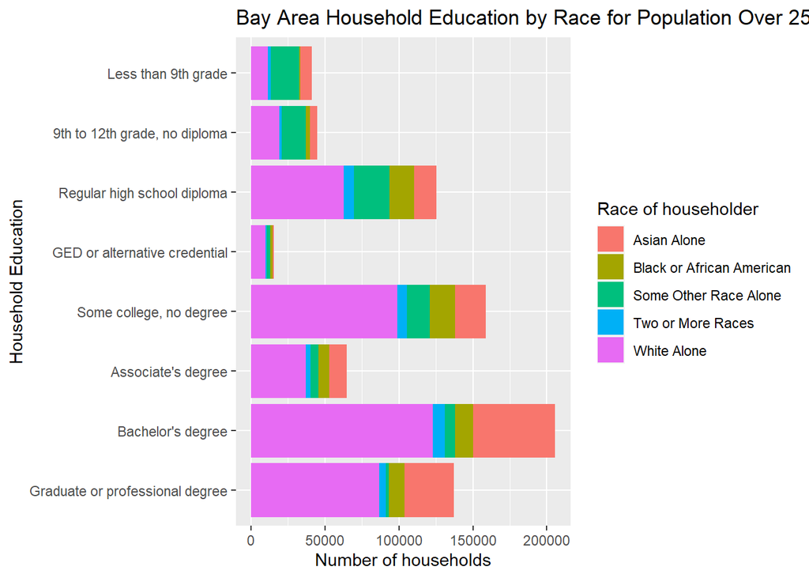

```r
bay_education_race %>%
  group_by(education, race) %>%
  ggplot() +
  geom_bar(
    aes(
      x = education %>% factor(levels = rev(bay_education_race$education[1:8])),
      y = estimate,
      fill = race
    ),
    stat = "identity",
    position = "stack"
  ) +
  labs(
    x = "Household Education",
    y = "Number of households",
    title = "Bay Area Household Education by Race for Population Over 25 Years Old",
    fill = "Race of householder"
  ) +
  coord_flip()
```

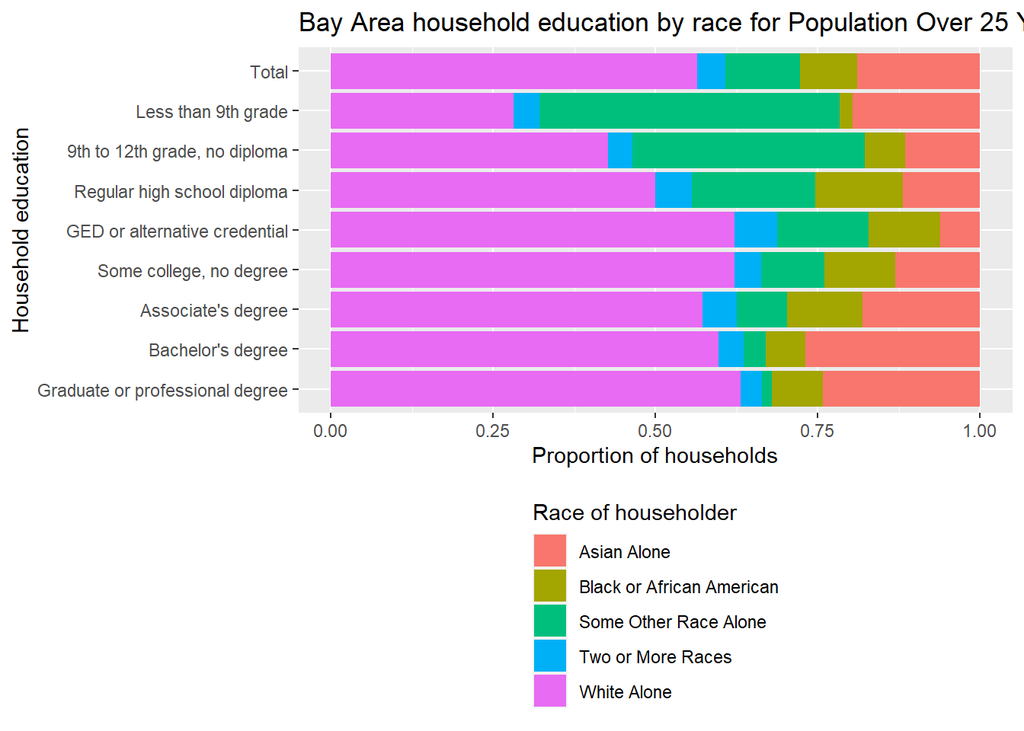

```r
bay_race_total <-
  bay_education_race %>%
  group_by(race) %>%
  mutate(education = "Total")

bay_education_race %>%
  group_by(education, race) %>%
  rbind(bay_race_total) %>%
  ggplot() +
  geom_bar(
    aes(
      x = education %>% factor(levels = rev(c("Total",bay_education_race$education[1:8]))),
      y = estimate,
      fill = race
    ),
    stat = "identity",
    position = "fill"
  ) +
  labs(
    x = "Household education",
    y = "Proportion of households",
    title = "Bay Area household education by race for Population Over 25 Years Old",
    fill = "Race of householder"
  ) +
  coord_flip() +
  theme(
    legend.position = "bottom",
    legend.direction = "vertical"
  )
```

## Contra Costa County Education by Gender for Population 25 Years and Older: Stacked and Filled Bar Charts

#### By looking at the filled bar chart below, we can see that there is a pretty equivalent education attainment by gender in Contra Costa County. Besides the GED level of education which had a higher proportion of males, the rest of the education levels were pretty equivalent gender wise to the total population proportions. This greatly contrasts with the distribution of education by race which was explored earlier. This might lead to the conclusion that for Contra Costa County, education has become more equalized across gender while it is still unproportional across race.

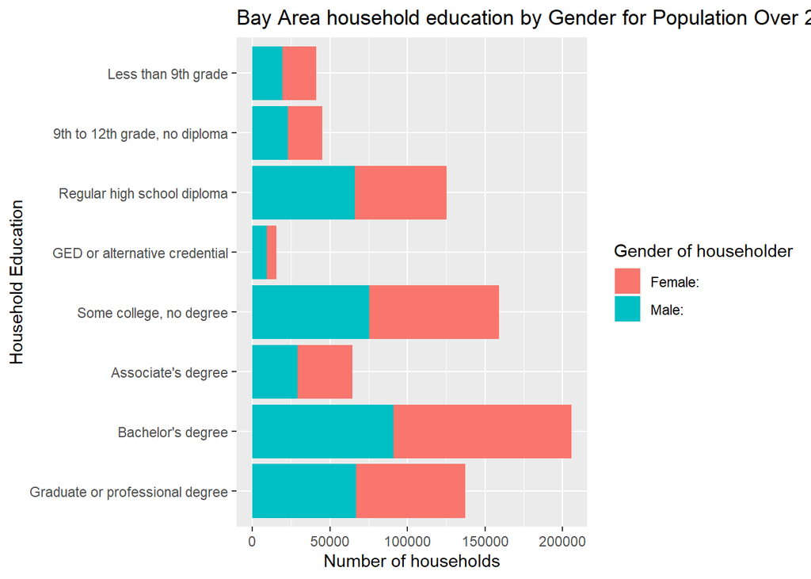

```r
bay_education_sex %>%
  group_by(education, sex) %>%
  ggplot() +
  geom_bar(
    aes(
      x = education %>% factor(levels = rev(bay_education_sex$education[1:8])),
      y = estimate,
      fill = sex
    ),
    stat = "identity",
    position = "stack"
  ) +
  labs(
    x = "Household Education",
    y = "Number of households",
    title = "Bay Area household education by Gender for Population Over 25 Years Old",
    fill = "Gender of householder"
  ) +
  coord_flip()
```

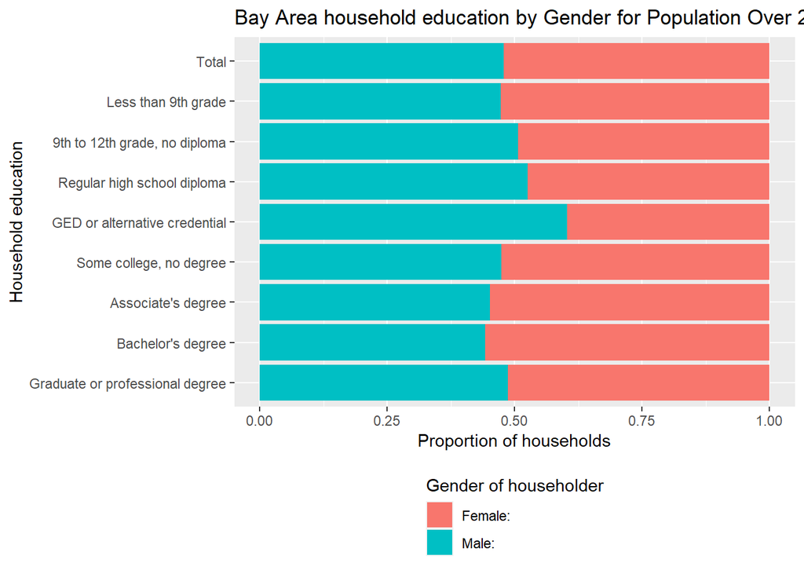

```r
bay_sex_total <-
  bay_education_sex %>%
  group_by(sex) %>%
  mutate(education = "Total")

bay_education_sex %>%
  group_by(education, sex) %>%
  rbind(bay_sex_total) %>%
  ggplot() +
  geom_bar(
    aes(
      x = education %>% factor(levels = rev(c("Total",bay_education_sex$education[1:8]))),
      y = estimate,
      fill = sex
    ),
    stat = "identity",
    position = "fill"
  ) +
  labs(
    x = "Household education",
    y = "Proportion of households",
    title = "Bay Area household education by Gender for Population Over 25 Years Old",
    fill = "Gender of householder"
  ) +
  coord_flip() +
  theme(
    legend.position = "bottom",
    legend.direction = "vertical"
  )
```

# Number and Percentage of K-12 students who have no internet access at home.

## Loading Pums Data

```r
# temp <- tempfile()
# download.file("https://www2.census.gov/programs-surveys/acs/data/pums/2019/1-Year/csv_hca.zip",destfile = temp, mode = "wb")
#
# pums_hca_2019_1yr <- read_csv(unzip(temp,"psam_h06.csv"))
#
# unlink(temp)
#
```

```r
# install.packages("devtools")
#
# devtools::install_github("walkerke/tidycensus")
```

```r
library(tidycensus)

census_api_key("c8aa67e4086b4b5ce3a8717f59faa9a28f611dab")

pums_vars_2019 <-
  pums_variables %>%
  filter(year == 2019, survey == "acs1")

pums_vars_2019_distinct_hh <-
  pums_vars_2019 %>%
  distinct(var_code, var_label, data_type, level) %>%
  filter(level == "housing")
```

```r
ca_pums <- get_pums(
  variables = c(
    "PUMA",
    "ACCESS",
    "AGEP",
    "SCHG"
  ),
  state = "CA",
  year = 2018,
  survey = "acs1",
  recode = T
)
```

## Selecting Counties and Pum’s Data

```r
bay_county_names <-
  c(
    "Alameda",
    "Contra Costa",
    "Marin",
    "Napa",
    "San Francisco",
    "San Mateo",
    "Santa Clara",
    "Solano",
    "Sonoma"
  )

bay_counties <-
  counties("CA", cb = T, progress_bar = F) %>%
  filter(NAME %in% bay_county_names)

ca_pumas <-
  pumas("CA", cb = T, progress_bar = F)

bay_pumas <-
  ca_pumas %>%
  st_centroid() %>%
  .[bay_counties, ] %>%
  st_set_geometry(NULL) %>%
  left_join(ca_pumas %>% select(GEOID10)) %>%
  st_as_sf()

bay_pums <-
  ca_pums %>%
  filter(PUMA %in% bay_pumas$PUMACE10)
```

## Map of the Percent of K-12th graders with no access to internet

```r
bay_pums_example <-
  bay_pums %>%
  mutate(
    SCHG = as.numeric(SCHG),
    no_access = ifelse(
      (ACCESS == "3") &
        (SCHG %in% 2:14),
      PWGTP,
      0
    )
  ) %>%
  group_by(PUMA) %>%
  summarize(
    perc_no_access =
      sum(no_access, na.rm =T)/sum(PWGTP, na.rm = T)*100
  ) %>%
  left_join(
    bay_pumas %>%
      select(PUMACE10),
    by = c("PUMA" = "PUMACE10")
  ) %>%
  st_as_sf()

pums_pal <- colorNumeric(
  palette = "Oranges",
  domain = bay_pums_example$perc_no_access
)

leaflet() %>%
  addTiles() %>%
  addPolygons(
    data = bay_pums_example,
    fillColor = ~pums_pal(perc_no_access),
    color = "white",
    opacity = 0.5,
    fillOpacity = 0.5,
    weight = 1,
    label = ~paste0(
      round(perc_no_access),
      "Percent of K-12th graders with no access to internet"
    ),
    highlightOptions = highlightOptions(
      weight = 2,
      opacity = 1
    )
  ) %>%
  addLegend(
    data = bay_pums_example,
    pal = pums_pal,
    values = ~perc_no_access,
    title = "Percent of K-12th<br>graders with no<br>access to internet"
  )
```

[interactive chart not shown]

## Map of the Number of K-12th graders with no access to internet

```r
bay_pums_example <-
  bay_pums %>%
  mutate(
    SCHG = as.numeric(SCHG),
    no_access = ifelse(
      (ACCESS == "3") &
        (SCHG %in% 2:14),
      PWGTP,
      0
    )
  ) %>%
  group_by(PUMA) %>%
  summarize(
    perc_no_access =
      sum(no_access, na.rm =T)
  ) %>%
  left_join(
    bay_pumas %>%
      select(PUMACE10),
    by = c("PUMA" = "PUMACE10")
  ) %>%
  st_as_sf()

pums_pal <- colorNumeric(
  palette = "Oranges",
  domain = bay_pums_example$perc_no_access
)

leaflet() %>%
  addTiles() %>%
  addPolygons(
    data = bay_pums_example,
    fillColor = ~pums_pal(perc_no_access),
    color = "white",
    opacity = 0.5,
    fillOpacity = 0.5,
    weight = 1,
    label = ~paste0(
      round(perc_no_access),
      "Number of K-12th graders with no access to internet"
    ),
    highlightOptions = highlightOptions(
      weight = 2,
      opacity = 1
    )
  ) %>%
  addLegend(
    data = bay_pums_example,
    pal = pums_pal,
    values = ~perc_no_access,
    title = "Number of K-12th<br>graders with no<br>access to internet"
  )
```

[interactive chart not shown]